# R Day report

The ‘R Day report’ article from the 2018-1 issue.

Fernando P. Mayer (

Laboratório de Estatística e Geoinformação - LEG/DEST/UFPR

) , Walmes M. Zeviani (

Laboratório de Estatística e Geoinformação - LEG/DEST/UFPR

) , Wagner H. Bonat (

Laboratório de Estatística e Geoinformação - LEG/DEST/UFPR

) , Elias T. Krainski (

Laboratório de Estatística e Geoinformação - LEG/DEST/UFPR

) , Paulo J. Ribeiro Jr (

Laboratório de Estatística e Geoinformação - LEG/DEST/UFPR

)  
2018-06-01

## 1 About

R Day[^1] - National Meeting of R Users, took place on May, 22, 2018 at Federal University of Paraná (UFPR), Curitiba, Brazil. It was the first event in Brazil endorsed by The R Foundation.

## 2 The event

R Day was planned as a satellite event of the 63rd RBRAS Annual Meeting[^2] of the Brazilian Region of The International Biometric Society[^3]. Paraná Federal University (UFPR) was selected on 2016 to host the meeting.

The R Day was considered as a UFPR *extension event*, and as such it was non-profitable and with no registration fees. There were 295 subscribed participants. Figure 1 shows how they split between students, professional and others.

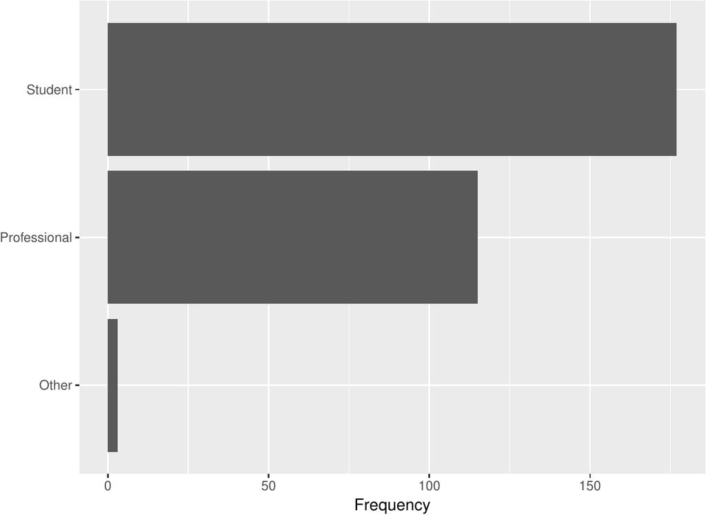

Figure 1: Number of subscribers by category.

Figure 2 shows the spread of the participants’ home locations, for 88 of those who have opted for make geocoding information available on the subscription form. There was quite a spread, with all of the five country regions represented, an encouraging achievement considering the continental distances within the country. The fact the event was an RBRAS satellite helped to gather a wider audience.

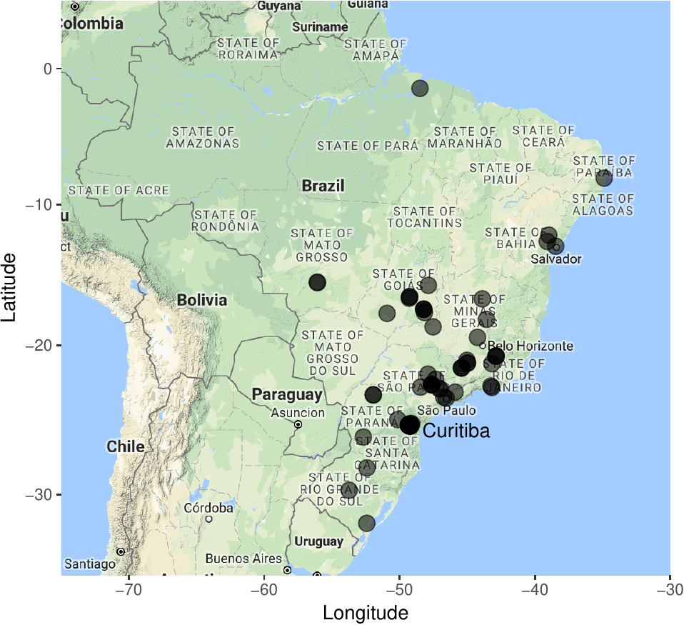

Figure 2: Home locations of the participants.

An important feature was that the event was meant to be guided by the community, opened for proposals for oral presentations and tutorials for which there were 25 and 14 proposals, respectively. Time and space restrictions allowed for the selections of 18 oral presentations and 8 tutorials contemplating a diversity of topics related to R.

Three speakers were invited by the organising committee. Paulo Justiniano Ribeiro Jr, senior lecture at the Department of Statistics at UFPR and LEG member gave an historical review mixed with his own experiences which are highly connected with the history of R in Brazil. The full video of his talk was made available at Youtube[^4]. Figure 3 captures a moment of Professor Paulo’s talk, reckon to be influential on the dissemination of R in Brazil.

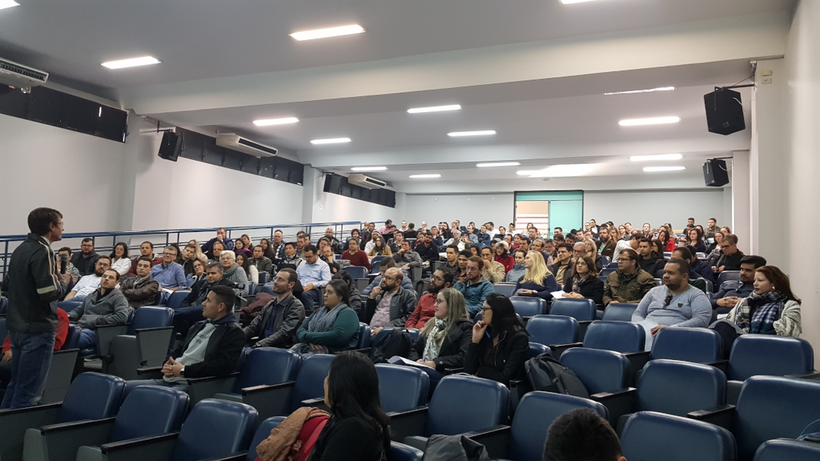

Figure 3: Prof. Paulo Justiniano (LEG) on the opening session.

Rondon de Andrade Porto, data scientist at the Conselho Nacional de Justiça - CNJ (National Justice Council), showed how R is used to generate a large volume of visualizations and dynamic reports on the CNJ.

The R Day final talk was made by Gabriela de Queiroz (via webconference) who can be seen in Figure 4. Gabriela is the founder of *R Ladies* and told us how it all started and how it became an important community for the diffusion of R in Brazil and worldwide. It was such an inspiring talk that a few days later, the R Ladies Curitiba chapter was founded[^5].

[figure not shown]

Figure 4: Gabriela de Queiroz (R Ladies) on the closing session.

The number of participants, well above our expectations, and all the positive and enthusiastic feedbacks shows a clear demand for events gathering the community of R users in Brazil. The existing community is large, diverse and spread around the country. The objective is to promote regular R Day events for sharing expert knowledge and experience, and stimulate and strength relationships and networks. Figure 5 shows some of the participants who were there after the closing session.

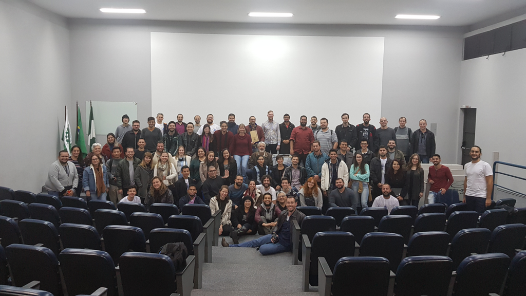

Figure 5: Some participants of R Day after the closing session.

Photos of the event are available at LEG’s page on Facebook[^6]. Slides, scripts and other materials used by the presenters are available at R Day[^7] web page.

## 3 Next steps

As R Day was so well received by the general community and by RBRAS meeting participants, the initial idea is to make R Day a regular satellite event. RBRAS meetings lasts for 3 days in even years, and for 5 days in odd years, and each year occurs in a different city of the country. That way, in even years, R Day could be organized in the city hosting the event. In odd years, we plan to make R Day in Curitiba, in a date that does not overlap with the RBRAS meeting, and maybe with 2 days duration.

## 4 Acknowledgements

We especially thank “The R Foundation” for endorsing R Day, particularly to Heather Turner, who contacted us and was always very kind and helpful to make this happen.

We thank all participants and the presenters, who offered to come voluntarily to make R Day a great event. Also, we would like to thank our sponsors[^8], who provided the financial support for coffee breaks.

We also thank RBRAS for the partnership and support in making R Day a satellite event of its annual meeting.

[^1]: http://rday.leg.ufpr.br
[^2]: http://www.rbras.org.br/rbras63/
[^3]: https://www.biometricsociety.org/
[^4]: https://www.youtube.com/watch?v=fnGvDEkjZy0
[^5]: https://www.meetup.com/pt-BR/rladies-curitiba
[^6]: https://www.facebook.com/leg.ufpr
[^7]: http://rday.leg.ufpr.br/materiais.html
[^8]: http://rday.leg.ufpr.br/apoio.html